# Intro to Quarto: RMarkdown file

2022-08-09

[figure not shown]

# Why Quarto?

If you already use markdown or RMarkdown, you may ask yourself “why switch to quarto?” As new quarto users, our switch has been mostly driven by improved access to a wide variety of formatting options and tools to make the code and documents we already write better.

This switch **also** revealed a lot of Rmarkdown tricks that we were not aware of, that carry over to Quarto as well.

## RMarkdown: The familiar

#### Behind the scenes:

When you press the `knit` button in Rstudio, the following chain of events unfolds behind the scene:

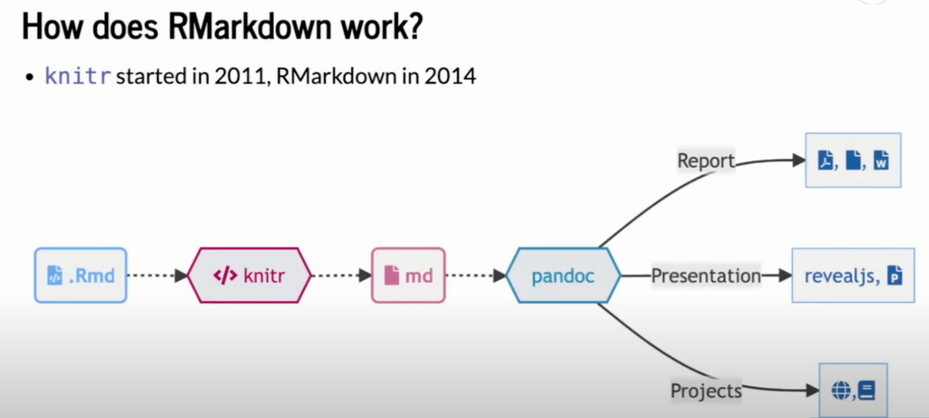

[source video](https://www.youtube.com/watch?v=yvi5uXQMvu4)

### This Tidal Exchanges Tutorial

We set up this “highly sophisticated” document to reflect the default features and formatting already available in RMarkdown. Use this as your starting point to try out the following:

- Transition an RMarkdown file into quarto
- Set figure options like sizing, alt. text, captions, and placement
- Set different formatting for PDF vs. HTML outputs
- Add custom CSS formatting for HTML outputs
- Explore options to include plots and figures, including alt-text
- Change document formatting to include interactivity, columns, and figure labels
- Change document font formatting
- Add citations & equations